# Accuracy study (Exponential data, Mann-Whitney U) - Compare p-value approximation methods

Compiled at 2026-02-05 14:32:30 UTC

## Load permApprox functions

## Method registry, file helpers, and per-method runner

### Relabeling helper

### Method registry

Methods, we will consider in this study:

- **Wilcoxon**: Wilcoxon test (Mann-Whitney U statistic is used here) (considered as ground truth)
- **Empirical**: Empirical p-values.
- **Empirical (pow3)**: Empirical p-values where the test statistics are raised to the power 3 (just to double-check the implementation).
- **Gamma**: Gamma approximation of the complete permutation distribution, as suggested by *Winkler et al.* (2016).
- **GPD (Knijnen)**: GPD approximation as suggested by *Knijnenburg et al. (2009)*:
  - GPD parameter estimation with one-parameter maximum likelihood estimation.
  - Threshold: Failure to reject (FTR), starting with 250 exceedances.
- **GPD (Knijnen, pow3)**: Like GPD(KB), but all test statistics are raised to the power 3 before GPD approximation, as suggested by Knijnenburg et al. (2009).
- **GPD (Winkler, +obs)**: Like GPD(KB), but $t_{obs}$ is included in the permutation distribution, as suggested by *Winkler et al.* (2016).
- **GPD (pApprox, UC)**: GPD approximation with permApprox as follows:
  - GPD parameter estimation using Likelihood-Moment-Estimation (LME).
  - Unconstrained (UC) parameter estimation.
  - Threshold: Robust failure to reject (robFTR), starting with 25% exceedances.
- **GPD(pApprox, ξ≥0)**: GPD approximation with permApprox as follows:
  - GPD parameter estimation with one-parameter maximum likelihood estimation.
  - Constraint: The shape parameter $\xi$ must be non-negative.
  - Threshold: Robust failure to reject (robFTR), starting with 25% exceedances.
- **GPD (pApprox, s>obs)**: Our proposed GPD approximation:
  - GPD parameter estimation using Likelihood-Moment-Estimation (LME).
  - Constraint: The support boundary $s$ must lie above the observed test statistic.
  - Threshold: Robust failure to reject (robFTR), starting with 25% exceedances.

For comparability, we use a **fitting threshold of 0.1** in all Gamma and GPD approximation settings, which is two times the classical $\alpha$ level of 0.05. That means, the fit is done if the empirical p-value is smaller than 0.1.

```r
# --- General method registry --------------------------------
# Edit here to add/remove methods or change labels/controls.
# Labels must match the plotting color names.
methods_registry <- list(
  wilcoxon = list(
    label  = "Wilcoxon",
    engine = "wilcoxon",
    params = list()
  ),

  empirical = list(
    label = "Empirical",
    engine = "empirical",
    params = list(
      power = 1
    )
  ),

  gamma = list(
    label  = "Gamma",
    engine = "gamma",
    params = list(
      gamma_ctrl = make_gamma_ctrl(
        include_obs   = FALSE,
        gof_test      = "none",
        gof_alpha     = 0.05
      )
    )
  ),

  gpd_knijnen = list(
    label  = "GPD (Knijnen)",
    engine = "gpd",
    params = list(
      power = 1,
      gpd_ctrl = make_gpd_ctrl(
        fit_method    = "MLE1D",
        tol           = 1e-10,
        include_obs   = FALSE,
        constraint    = "unconstrained",
        thresh_method = "ftr", # Failure to reject
        exceed0       = 250, # Start at 250 exceedances
        exceed0_min   = 0,
        exceed_min    = 10,
        thresh_step   = 10, # Increment by 10 if gof test fails
        gof_test      = "ad",
        gof_alpha     = 0.05,
        cores         = 1,
        verbose       = FALSE
      )
    )
  ),

  gpd_knijnen_pow3 = list(
    label  = "GPD (Knijnen, pow3)",
    engine = "gpd",
    params = list(
      power = 3,
      gpd_ctrl = make_gpd_ctrl(
        fit_method    = "MLE1D",
        tol           = 1e-10,
        include_obs   = FALSE,
        constraint    = "unconstrained",
        thresh_method = "ftr", # Failure to reject
        exceed0       = 250, # Start at 250 exceedances
        exceed0_min   = 0,
        exceed_min    = 10,
        thresh_step   = 10, # Increment by 10 if gof test fails
        gof_test      = "ad",
        gof_alpha     = 0.05,
        cores         = 1,
        verbose       = FALSE
      )
    )
  ),

  gpd_incl_obs = list(
    label  = "GPD (Winkler, +obs)",
    engine = "gpd",
    params = list(
      power = 1,
      gpd_ctrl = make_gpd_ctrl(
        fit_method    = "MLE1D",
        tol           = 1e-10,
        include_obs   = TRUE,
        constraint    = "unconstrained",
        thresh_method = "ftr", # Failure to reject
        exceed0       = 0.25, # Start at 0.25B exceedances
        exceed0_min   = 0,
        exceed_min    = 10,
        thresh_step   = 10, # Increment by 10 if gof test fails
        gof_test      = "ad",
        gof_alpha     = 0.05,
        cores         = 1,
        verbose       = FALSE
      )
    )
  ),

  gpd_papprox_uc = list(
    label  = "GPD (pApprox, UC)",
    engine = "gpd",
    params = list(
      power = 1,
      gpd_ctrl = make_gpd_ctrl(
        fit_method    = "LME",
        tol           = 1e-7,
        include_obs   = FALSE,
        constraint    = "unconstrained",
        thresh_method = "rob_ftr", # Failure to reject
        exceed0       = 0.25, # Start with 25% exceedances
        exceed0_min   = 250, # Use minimum 250 exceedances
        exceed_min    = 10,
        thresh_step   = 10, # Increment by 10 if gof test fails
        gof_test      = "ad",
        gof_alpha     = 0.05,
        cores         = 1,
        verbose       = FALSE
      )
    )
  ),

  gpd_papprox_xi_pos = list(
    label  = "GPD (pApprox, ξ≥0)",
    engine = "gpd",
    params = list(
      power = 1,
      gpd_ctrl = make_gpd_ctrl(
        fit_method    = "MLE1D",
        tol           = 1e-10,
        include_obs   = FALSE,
        constraint    = "shape_nonneg",
        thresh_method = "rob_ftr", # Failure to reject
        exceed0       = 0.25, # Start with 25% exceedances
        exceed0_min   = 250, # Use minimum 250 exceedances
        exceed_min    = 10,
        thresh_step   = 10, # Increment by 10 if gof test fails
        gof_test      = "ad",
        gof_alpha     = 0.05,
        cores         = 1,
        verbose       = FALSE
      )
    )
  ),

  gpd_papprox_supp_at_obs = list(
    label  = "GPD (pApprox, s>obs)",
    engine = "gpd",
    params = list(
      power = 1,
      gpd_ctrl = make_gpd_ctrl(
        fit_method    = "LME",
        tol           = 1e-7,
        include_obs   = FALSE,
        constraint    = "support_at_obs",
        thresh_method = "rob_ftr", # Failure to reject
        exceed0       = 0.25, # Start with 25% exceedances
        exceed0_min   = 250, # Use minimum 250 exceedances
        exceed_min    = 10,
        thresh_step   = 10, # Increment by 10 if gof test fails
        gof_test      = "ad",
        gof_alpha     = 0.05,
        cores         = 1,
        verbose       = FALSE
      )
    )
  )
)

# Labels (used later for factor order)
method_labels <- vapply(methods_registry, `[[`, "", "label")

# move "t-test" label to the end
i_wilcox <- which(method_labels == "Wilcoxon")
method_labels <- c(method_labels[-i_wilcox], method_labels[i_wilcox])

# Filter method(s)
# methods_registry_sub <- list(
#   gamma = methods_registry$gamma
# )
# methods_registry <- methods_registry_sub
```

### Engines

```r
# Engine for the Wilcoxon / Mann-Whitney U test
.engine_wilcox <- function(lst_panels, n, d, n_perm, study_str, label,
                           method_key, pi1 = NA_real_) {
  purrr::imap_dfr(lst_panels, function(panel, rep_id) {
    n_test <- nrow(panel)
    stopifnot(ncol(panel) == n_perm + 2)
    # U data: columns 1:n_perm, "uobs", "p_wilcox"
    colnames(panel) <- c(as.character(seq_len(n_perm)), "uobs", "p_wilcox")

    tibble(
      study    = gsub("^acc_", "", study_str),
      n, d, n_perm, pi1,
      rep      = rep_id,
      test_idx = seq_len(n_test),
      method   = label,
      pval     = as.numeric(panel[, "p_wilcox"]),  # asymptotic Wilcoxon p
      gpd_shape = NA_real_,
      gpd_scale = NA_real_,
      gpd_bound = NA_real_,
      meth_used = NA_character_,
      n_exceed  = NA_integer_
    )
  })
}


.engine_empirical <- function(lst_panels, n, d, n_perm, study_str, label,
                              method_key, params, pi1 = NA_real_) {
  power <- params$power

  purrr::imap_dfr(lst_panels, function(panel, rep_id) {
    n_test <- nrow(panel)
    stopifnot(ncol(panel) == n_perm + 2)
    colnames(panel) <- c(as.character(seq_len(n_perm)), "uobs", "p_wilcox")

    perm_mat <- t(as.matrix(panel[, seq_len(n_perm), drop = FALSE]))  # (B x m)
    tobs_vec <- as.numeric(panel[, "uobs"])

    fit <- compute_p_values(
      obs_stats     = tobs_vec,
      perm_stats    = perm_mat,
      alternative   = "two_sided",
      null_center   = "mean",
      method        = "empirical",
      power         = power,
      adjust_method = "none"
    )

    tibble(
      study     = gsub("^acc_", "", study_str),
      n, d, n_perm, pi1,
      rep       = rep_id,
      test_idx  = seq_len(n_test),
      method    = label,
      pval      = fit$p_unadjusted,
      gpd_shape = NA_real_,
      gpd_scale = NA_real_,
      gpd_bound = NA_real_,
      meth_used = fit$method_used,
      n_exceed  = NA_integer_
    )
  })
}

.engine_gamma <- function(lst_panels, n, d, n_perm, study_str, label,
                              method_key, params, pi1 = NA_real_) {
  gamma_ctrl <- params$gamma_ctrl
  purrr::imap_dfr(lst_panels, function(panel, rep_id) {
    n_test <- nrow(panel)
    stopifnot(ncol(panel) == n_perm + 2)
    colnames(panel) <- c(as.character(seq_len(n_perm)), "uobs", "p_wilcox")

    perm_mat <- t(as.matrix(panel[, seq_len(n_perm), drop = FALSE]))  # (B x m)
    tobs_vec <- as.numeric(panel[, "uobs"])

    fit <- compute_p_values(
      obs_stats     = (tobs_vec/100),
      perm_stats    = (perm_mat/100),# Gamma fit fails if test statistics are too large
      alternative   = "two_sided",
      null_center   = "mean",
      method        = "gamma",
      fit_thresh    = 0.1, # Twice the standard alpha level
      gamma_ctrl    = gamma_ctrl,
      adjust_method = "none"
    )

    tibble(
      study     = gsub("^acc_", "", study_str),
      n, d, n_perm, pi1,
      rep       = rep_id,
      test_idx  = seq_len(n_test),
      method    = label,
      pval      = fit$p_unadjusted,
      gpd_shape = NA_real_,
      gpd_scale = NA_real_,
      gpd_bound = NA_real_,
      meth_used = fit$method_used,
      n_exceed  = NA_integer_
    )
  })
}

.engine_gpd <- function(lst_panels, n, d, n_perm, study_str, label,
                        method_key, params, pi1 = NA_real_) {
  gpd_ctrl <- params$gpd_ctrl
  power <- params$power

  purrr::imap_dfr(lst_panels, function(panel, rep_id) {
    n_test <- nrow(panel)
    stopifnot(ncol(panel) == n_perm + 2)
    colnames(panel) <- c(as.character(seq_len(n_perm)), "uobs", "p_wilcox")

    perm_mat <- t(as.matrix(panel[, seq_len(n_perm), drop = FALSE]))  # (B x m)
    tobs_vec <- as.numeric(panel[, "uobs"])

    fit <- compute_p_values(
      obs_stats     = tobs_vec,
      perm_stats    = perm_mat,
      eps_fct       = eps_slls_perm,
      sampsize      = n,
      alternative   = "two_sided",
      null_center   = "mean",
      method        = "gpd",
      fit_thresh    = 0.1, # Twice the alpha level
      power         = power,
      gpd_ctrl      = gpd_ctrl,
      adjust_method = "none"
    )

    if(!is.null(fit$gpd_fit)) {
      shape <- fit$gpd_fit$shape
      scale <- fit$gpd_fit$scale
      bound <- ifelse(shape < 0, -scale / shape, NA_real_)
    } else {
      shape <- scale <- bound <- NA_real_
    }

    tibble(
      study     = gsub("^acc_", "", study_str),
      n, d, n_perm, pi1,
      rep       = rep_id,
      test_idx  = seq_len(n_test),
      method    = label,
      pval      = fit$p_unadjusted,
      gpd_shape = shape,
      gpd_scale = scale,
      gpd_bound = bound,
      meth_used = fit$method_used,
      n_exceed  = fit$gpd_fit$n_exceed
    )
  })
}

# (Other engines like empirical/custom can be added here)

# --- Dispatcher ---------------------------------------------------------------
run_method_engine <- function(method_key, def, lst_panels, n, d, n_perm,
                              study_str, pi1 = NA_real_) {
  engine <- def$engine
  label  <- def$label
  params <- def$params %||% list()

  switch(engine,
         wilcoxon  = .engine_wilcox(lst_panels, n, d, n_perm, study_str,
                                   label, method_key, pi1),
         empirical = .engine_empirical(lst_panels, n, d, n_perm, study_str,
                                       label, method_key, params, pi1),
         gamma     = .engine_gamma(lst_panels, n, d, n_perm, study_str,
                                   label, method_key, params, pi1),
         gpd       = .engine_gpd(lst_panels, n, d, n_perm, study_str,
                                 label, method_key, params, pi1),
         stop(sprintf("Unknown engine: %s", engine))
  )
}
```

### Output path builders

## ACCURACY

### Compute p-values and save

### Collect & reshape

### Plotting helper

### Filter, rename + colors

### By sample size (n)

#### P-values

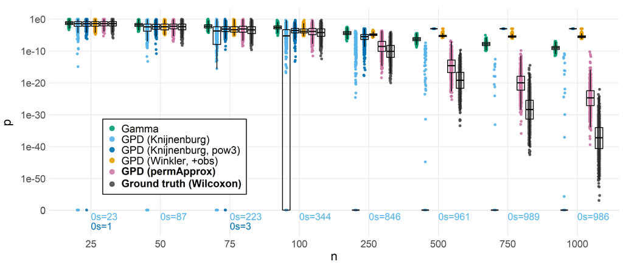

#### Ratios (method vs. Wilcoxon)

Ratios ($p_{method}$ / $p_{wilcox}$) for non-zero p-values, with sample size on the x axis.

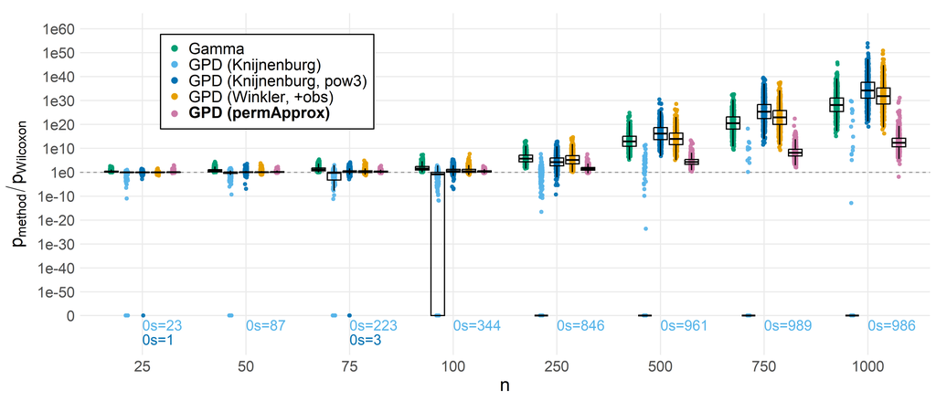

### P-values by d and B

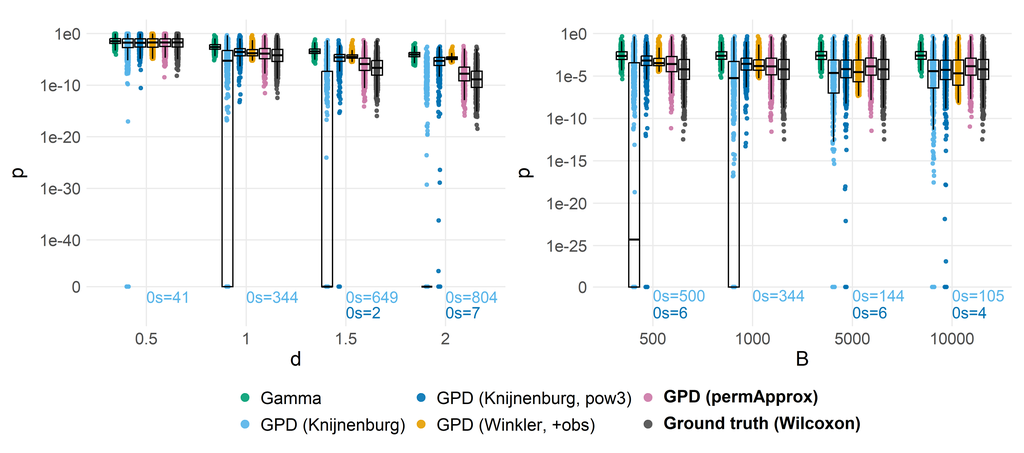

### Ratios by d and B

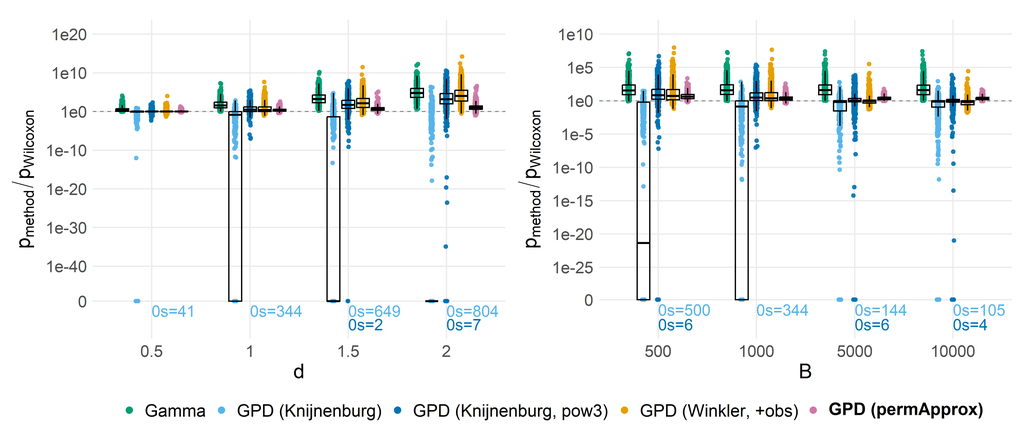

### Table: Accuracy metrics

Accuracy vs. Wilcoxon by n (d=1, B=1000).

| n | method | N | bias | sd | rmse | cor_spear | N_pos |
| --- | --- | --- | --- | --- | --- | --- | --- |
| 25 | Gamma | 1000 | 9.91e-03 | 1.33e-02 | 1.66e-02 | 0.997 | 1000 |
| 25 | GPD (Winkler, +obs) | 1000 | 1.09e-03 | 1.22e-02 | 1.22e-02 | 0.995 | 1000 |
| 25 | GPD (Knijnenburg) | 1000 | 8.71e-04 | 1.22e-02 | 1.22e-02 | 0.995 | 977 |
| 25 | GPD (Knijnenburg, pow3) | 1000 | 3.84e-04 | 1.23e-02 | 1.23e-02 | 0.995 | 999 |
| 25 | GPD (permApprox) | 1000 | 9.92e-04 | 1.23e-02 | 1.23e-02 | 0.996 | 1000 |
| 50 | Gamma | 1000 | 9.10e-03 | 8.56e-03 | 1.25e-02 | 0.996 | 1000 |
| 50 | GPD (Winkler, +obs) | 1000 | 3.96e-04 | 6.42e-03 | 6.43e-03 | 0.982 | 1000 |
| 50 | GPD (Knijnenburg) | 1000 | 1.46e-04 | 6.42e-03 | 6.42e-03 | 0.978 | 913 |
| 50 | GPD (Knijnenburg, pow3) | 1000 | -1.77e-04 | 6.47e-03 | 6.47e-03 | 0.981 | 1000 |
| 50 | GPD (permApprox) | 1000 | 6.49e-04 | 6.38e-03 | 6.41e-03 | 0.994 | 1000 |
| 75 | Gamma | 1000 | 6.26e-03 | 6.69e-03 | 9.16e-03 | 0.993 | 1000 |
| 75 | GPD (Winkler, +obs) | 1000 | -5.09e-05 | 3.69e-03 | 3.69e-03 | 0.938 | 1000 |
| 75 | GPD (Knijnenburg) | 1000 | -2.55e-04 | 3.68e-03 | 3.69e-03 | 0.908 | 777 |
| 75 | GPD (Knijnenburg, pow3) | 1000 | -2.41e-04 | 3.73e-03 | 3.73e-03 | 0.930 | 997 |
| 75 | GPD (permApprox) | 1000 | 2.61e-04 | 3.69e-03 | 3.69e-03 | 0.989 | 1000 |
| 100 | Gamma | 1000 | 4.34e-03 | 5.03e-03 | 6.64e-03 | 0.990 | 1000 |
| 100 | GPD (Winkler, +obs) | 1000 | 6.31e-05 | 1.81e-03 | 1.81e-03 | 0.907 | 1000 |
| 100 | GPD (Knijnenburg) | 1000 | -9.65e-05 | 1.80e-03 | 1.80e-03 | 0.836 | 656 |
| 100 | GPD (Knijnenburg, pow3) | 1000 | 9.26e-06 | 1.85e-03 | 1.85e-03 | 0.898 | 1000 |
| 100 | GPD (permApprox) | 1000 | 1.97e-04 | 1.79e-03 | 1.80e-03 | 0.986 | 1000 |
| 250 | Gamma | 1000 | 1.38e-04 | 2.92e-04 | 3.23e-04 | 0.967 | 1000 |
| 250 | GPD (Winkler, +obs) | 1000 | 2.16e-05 | 2.87e-05 | 3.59e-05 | 0.598 | 1000 |
| 250 | GPD (Knijnenburg) | 1000 | 1.67e-07 | 6.49e-06 | 6.48e-06 | 0.263 | 154 |
| 250 | GPD (Knijnenburg, pow3) | 1000 | 4.00e-05 | 1.54e-04 | 1.59e-04 | 0.527 | 1000 |
| 250 | GPD (permApprox) | 1000 | 1.53e-06 | 9.22e-06 | 9.35e-06 | 0.946 | 1000 |
| 500 | Gamma | 1000 | 1.68e-06 | 3.42e-06 | 3.81e-06 | 0.935 | 1000 |
| 500 | GPD (Winkler, +obs) | 1000 | 1.49e-05 | 8.34e-05 | 8.47e-05 | 0.349 | 1000 |
| 500 | GPD (Knijnenburg) | 1000 | 4.80e-11 | 1.15e-09 | 1.15e-09 | 0.094 | 39 |
| 500 | GPD (Knijnenburg, pow3) | 1000 | 9.99e-04 | 5.92e-12 | 9.99e-04 | NA | 1000 |
| 500 | GPD (permApprox) | 1000 | 3.50e-10 | 6.07e-09 | 6.07e-09 | 0.911 | 1000 |
| 750 | Gamma | 1000 | 6.75e-08 | 3.11e-07 | 3.18e-07 | 0.893 | 1000 |
| 750 | GPD (Winkler, +obs) | 1000 | 1.97e-05 | 1.17e-04 | 1.19e-04 | 0.164 | 1000 |
| 750 | GPD (Knijnenburg) | 1000 | 2.70e-16 | 8.18e-15 | 8.18e-15 | 0.018 | 11 |
| 750 | GPD (Knijnenburg, pow3) | 1000 | 9.99e-04 | 9.92e-17 | 9.99e-04 | NA | 1000 |
| 750 | GPD (permApprox) | 1000 | 1.67e-13 | 4.50e-12 | 4.51e-12 | 0.869 | 1000 |
| 1000 | Gamma | 1000 | 3.68e-09 | 9.42e-09 | 1.01e-08 | 0.865 | 1000 |
| 1000 | GPD (Winkler, +obs) | 1000 | 4.24e-05 | 1.88e-04 | 1.92e-04 | 0.106 | 1000 |
| 1000 | GPD (Knijnenburg) | 1000 | 2.24e-14 | 5.08e-13 | 5.09e-13 | 0.001 | 14 |
| 1000 | GPD (Knijnenburg, pow3) | 1000 | 9.99e-04 | 0.00e+00 | 9.99e-04 | NA | 1000 |
| 1000 | GPD (permApprox) | 1000 | 1.24e-13 | 2.47e-12 | 2.48e-12 | 0.825 | 1000 |

Accuracy vs. Wilcoxon across all settings.

| n | d | B | method | N | bias | sd | rmse | cor_spear | N_pos |
| --- | --- | --- | --- | --- | --- | --- | --- | --- | --- |
| 25 | 1.0 | 1000 | Gamma | 1000 | 9.91e-03 | 1.33e-02 | 1.66e-02 | 0.997 | 1000 |
| 25 | 1.0 | 1000 | GPD (Winkler, +obs) | 1000 | 1.09e-03 | 1.22e-02 | 1.22e-02 | 0.995 | 1000 |
| 25 | 1.0 | 1000 | GPD (Knijnenburg) | 1000 | 8.71e-04 | 1.22e-02 | 1.22e-02 | 0.995 | 977 |
| 25 | 1.0 | 1000 | GPD (Knijnenburg, pow3) | 1000 | 3.84e-04 | 1.23e-02 | 1.23e-02 | 0.995 | 999 |
| 25 | 1.0 | 1000 | GPD (permApprox) | 1000 | 9.92e-04 | 1.23e-02 | 1.23e-02 | 0.996 | 1000 |
| 50 | 1.0 | 1000 | Gamma | 1000 | 9.10e-03 | 8.56e-03 | 1.25e-02 | 0.996 | 1000 |
| 50 | 1.0 | 1000 | GPD (Winkler, +obs) | 1000 | 3.96e-04 | 6.42e-03 | 6.43e-03 | 0.982 | 1000 |
| 50 | 1.0 | 1000 | GPD (Knijnenburg) | 1000 | 1.46e-04 | 6.42e-03 | 6.42e-03 | 0.978 | 913 |
| 50 | 1.0 | 1000 | GPD (Knijnenburg, pow3) | 1000 | -1.77e-04 | 6.47e-03 | 6.47e-03 | 0.981 | 1000 |
| 50 | 1.0 | 1000 | GPD (permApprox) | 1000 | 6.49e-04 | 6.38e-03 | 6.41e-03 | 0.994 | 1000 |
| 75 | 1.0 | 1000 | Gamma | 1000 | 6.26e-03 | 6.69e-03 | 9.16e-03 | 0.993 | 1000 |
| 75 | 1.0 | 1000 | GPD (Winkler, +obs) | 1000 | -5.09e-05 | 3.69e-03 | 3.69e-03 | 0.938 | 1000 |
| 75 | 1.0 | 1000 | GPD (Knijnenburg) | 1000 | -2.55e-04 | 3.68e-03 | 3.69e-03 | 0.908 | 777 |
| 75 | 1.0 | 1000 | GPD (Knijnenburg, pow3) | 1000 | -2.41e-04 | 3.73e-03 | 3.73e-03 | 0.930 | 997 |
| 75 | 1.0 | 1000 | GPD (permApprox) | 1000 | 2.61e-04 | 3.69e-03 | 3.69e-03 | 0.989 | 1000 |
| 100 | 0.5 | 1000 | Gamma | 1000 | 9.37e-03 | 1.22e-02 | 1.53e-02 | 0.997 | 1000 |
| 100 | 0.5 | 1000 | GPD (Winkler, +obs) | 1000 | 7.30e-04 | 1.05e-02 | 1.06e-02 | 0.993 | 1000 |
| 100 | 0.5 | 1000 | GPD (Knijnenburg) | 1000 | 5.01e-04 | 1.06e-02 | 1.06e-02 | 0.992 | 959 |
| 100 | 0.5 | 1000 | GPD (Knijnenburg, pow3) | 1000 | -3.50e-05 | 1.06e-02 | 1.06e-02 | 0.992 | 1000 |
| 100 | 0.5 | 1000 | GPD (permApprox) | 1000 | 8.49e-04 | 1.05e-02 | 1.06e-02 | 0.996 | 1000 |
| 100 | 1.0 | 500 | Gamma | 1000 | 4.23e-03 | 5.15e-03 | 6.66e-03 | 0.981 | 1000 |
| 100 | 1.0 | 500 | GPD (Winkler, +obs) | 1000 | 2.28e-04 | 2.64e-03 | 2.65e-03 | 0.866 | 1000 |
| 100 | 1.0 | 500 | GPD (Knijnenburg) | 1000 | -8.67e-05 | 2.57e-03 | 2.57e-03 | 0.803 | 500 |
| 100 | 1.0 | 500 | GPD (Knijnenburg, pow3) | 1000 | 4.76e-04 | 2.92e-03 | 2.96e-03 | 0.843 | 994 |
| 100 | 1.0 | 500 | GPD (permApprox) | 1000 | 7.70e-04 | 2.75e-03 | 2.85e-03 | 0.982 | 1000 |
| 100 | 1.0 | 1000 | Gamma | 1000 | 4.34e-03 | 5.03e-03 | 6.64e-03 | 0.990 | 1000 |
| 100 | 1.0 | 1000 | GPD (Winkler, +obs) | 1000 | 6.31e-05 | 1.81e-03 | 1.81e-03 | 0.907 | 1000 |
| 100 | 1.0 | 1000 | GPD (Knijnenburg) | 1000 | -9.65e-05 | 1.80e-03 | 1.80e-03 | 0.836 | 656 |
| 100 | 1.0 | 1000 | GPD (Knijnenburg, pow3) | 1000 | 9.26e-06 | 1.85e-03 | 1.85e-03 | 0.898 | 1000 |
| 100 | 1.0 | 1000 | GPD (permApprox) | 1000 | 1.97e-04 | 1.79e-03 | 1.80e-03 | 0.986 | 1000 |
| 100 | 1.0 | 5000 | Gamma | 1000 | 4.41e-03 | 4.89e-03 | 6.58e-03 | 0.998 | 1000 |
| 100 | 1.0 | 5000 | GPD (Winkler, +obs) | 1000 | 3.68e-05 | 9.76e-04 | 9.77e-04 | 0.973 | 1000 |
| 100 | 1.0 | 5000 | GPD (Knijnenburg) | 1000 | -3.58e-05 | 9.57e-04 | 9.57e-04 | 0.926 | 856 |
| 100 | 1.0 | 5000 | GPD (Knijnenburg, pow3) | 1000 | -3.60e-05 | 9.66e-04 | 9.67e-04 | 0.947 | 994 |
| 100 | 1.0 | 5000 | GPD (permApprox) | 1000 | 2.57e-04 | 9.80e-04 | 1.01e-03 | 0.997 | 1000 |
| 100 | 1.0 | 10000 | Gamma | 1000 | 4.43e-03 | 4.85e-03 | 6.57e-03 | 0.999 | 1000 |
| 100 | 1.0 | 10000 | GPD (Winkler, +obs) | 1000 | 4.18e-05 | 6.36e-04 | 6.37e-04 | 0.979 | 1000 |
| 100 | 1.0 | 10000 | GPD (Knijnenburg) | 1000 | -2.36e-05 | 5.93e-04 | 5.93e-04 | 0.942 | 895 |
| 100 | 1.0 | 10000 | GPD (Knijnenburg, pow3) | 1000 | -1.96e-05 | 5.88e-04 | 5.89e-04 | 0.958 | 996 |
| 100 | 1.0 | 10000 | GPD (permApprox) | 1000 | 2.61e-04 | 6.67e-04 | 7.16e-04 | 0.998 | 1000 |
| 100 | 1.5 | 1000 | Gamma | 1000 | 9.86e-04 | 1.80e-03 | 2.05e-03 | 0.980 | 1000 |
| 100 | 1.5 | 1000 | GPD (Winkler, +obs) | 1000 | 5.07e-05 | 2.15e-04 | 2.21e-04 | 0.760 | 1000 |
| 100 | 1.5 | 1000 | GPD (Knijnenburg) | 1000 | -1.09e-05 | 2.04e-04 | 2.04e-04 | 0.546 | 351 |
| 100 | 1.5 | 1000 | GPD (Knijnenburg, pow3) | 1000 | 7.31e-05 | 2.89e-04 | 2.98e-04 | 0.710 | 998 |
| 100 | 1.5 | 1000 | GPD (permApprox) | 1000 | 3.93e-05 | 2.06e-04 | 2.09e-04 | 0.966 | 1000 |
| 100 | 2.0 | 1000 | Gamma | 1000 | 2.35e-04 | 5.32e-04 | 5.81e-04 | 0.972 | 1000 |
| 100 | 2.0 | 1000 | GPD (Winkler, +obs) | 1000 | 2.70e-05 | 4.16e-05 | 4.96e-05 | 0.618 | 1000 |
| 100 | 2.0 | 1000 | GPD (Knijnenburg) | 1000 | -3.41e-07 | 2.14e-05 | 2.14e-05 | 0.336 | 196 |
| 100 | 2.0 | 1000 | GPD (Knijnenburg, pow3) | 1000 | 2.64e-05 | 6.86e-05 | 7.35e-05 | 0.564 | 993 |
| 100 | 2.0 | 1000 | GPD (permApprox) | 1000 | 4.73e-06 | 3.72e-05 | 3.75e-05 | 0.945 | 1000 |
| 250 | 1.0 | 1000 | Gamma | 1000 | 1.38e-04 | 2.92e-04 | 3.23e-04 | 0.967 | 1000 |
| 250 | 1.0 | 1000 | GPD (Winkler, +obs) | 1000 | 2.16e-05 | 2.87e-05 | 3.59e-05 | 0.598 | 1000 |
| 250 | 1.0 | 1000 | GPD (Knijnenburg) | 1000 | 1.67e-07 | 6.49e-06 | 6.48e-06 | 0.263 | 154 |
| 250 | 1.0 | 1000 | GPD (Knijnenburg, pow3) | 1000 | 4.00e-05 | 1.54e-04 | 1.59e-04 | 0.527 | 1000 |
| 250 | 1.0 | 1000 | GPD (permApprox) | 1000 | 1.53e-06 | 9.22e-06 | 9.35e-06 | 0.946 | 1000 |
| 500 | 1.0 | 1000 | Gamma | 1000 | 1.68e-06 | 3.42e-06 | 3.81e-06 | 0.935 | 1000 |
| 500 | 1.0 | 1000 | GPD (Winkler, +obs) | 1000 | 1.49e-05 | 8.34e-05 | 8.47e-05 | 0.349 | 1000 |
| 500 | 1.0 | 1000 | GPD (Knijnenburg) | 1000 | 4.80e-11 | 1.15e-09 | 1.15e-09 | 0.094 | 39 |
| 500 | 1.0 | 1000 | GPD (Knijnenburg, pow3) | 1000 | 9.99e-04 | 5.92e-12 | 9.99e-04 | NA | 1000 |
| 500 | 1.0 | 1000 | GPD (permApprox) | 1000 | 3.50e-10 | 6.07e-09 | 6.07e-09 | 0.911 | 1000 |
| 750 | 1.0 | 1000 | Gamma | 1000 | 6.75e-08 | 3.11e-07 | 3.18e-07 | 0.893 | 1000 |
| 750 | 1.0 | 1000 | GPD (Winkler, +obs) | 1000 | 1.97e-05 | 1.17e-04 | 1.19e-04 | 0.164 | 1000 |
| 750 | 1.0 | 1000 | GPD (Knijnenburg) | 1000 | 2.70e-16 | 8.18e-15 | 8.18e-15 | 0.018 | 11 |
| 750 | 1.0 | 1000 | GPD (Knijnenburg, pow3) | 1000 | 9.99e-04 | 9.92e-17 | 9.99e-04 | NA | 1000 |
| 750 | 1.0 | 1000 | GPD (permApprox) | 1000 | 1.67e-13 | 4.50e-12 | 4.51e-12 | 0.869 | 1000 |
| 1000 | 1.0 | 1000 | Gamma | 1000 | 3.68e-09 | 9.42e-09 | 1.01e-08 | 0.865 | 1000 |
| 1000 | 1.0 | 1000 | GPD (Winkler, +obs) | 1000 | 4.24e-05 | 1.88e-04 | 1.92e-04 | 0.106 | 1000 |
| 1000 | 1.0 | 1000 | GPD (Knijnenburg) | 1000 | 2.24e-14 | 5.08e-13 | 5.09e-13 | 0.001 | 14 |
| 1000 | 1.0 | 1000 | GPD (Knijnenburg, pow3) | 1000 | 9.99e-04 | 0.00e+00 | 9.99e-04 | NA | 1000 |
| 1000 | 1.0 | 1000 | GPD (permApprox) | 1000 | 1.24e-13 | 2.47e-12 | 2.48e-12 | 0.825 | 1000 |

## Files written

These files have been written to the target directory, `data/02_p_approx_methods`:

```
## # A tibble: 2 × 4
##   path       type             size modification_time
##   <fs::path> <fct>     <fs::bytes> <dttm>
## 1 accuracy   directory           0 2026-02-05 13:56:22
## 2 gamma_old  directory           0 2026-02-05 12:41:04
```